# R Competency Check #4

Scott Dolan

9/15/2020

# PMF of a 5 Question True/False Test

> A test consists of five true-false problems. A reasonable model for the answer given by a student who has not studied assumes that each question is marked T or F by flipping a coin. Thus, any 5-long binary sequence of 0’s (incorrect) and 1’s (correct), that is, points received in each of the five questions, is equally likely. Let X denote the test score of such a student. Use R to do the following:
> 1. Create an expanded grid of all possible outcomes (0’s and 1’s).

```r
allOutcomes <- expand.grid(X1=0:1, X2=0:1, X3=0:1, X4=0:1, X5=0:1)
allOutcomes
```

| X1 | X2 | X3 | X4 | X5 |
| --- | --- | --- | --- | --- |
| 0 | 0 | 0 | 0 | 0 |
| 1 | 0 | 0 | 0 | 0 |
| 0 | 1 | 0 | 0 | 0 |
| 1 | 1 | 0 | 0 | 0 |
| 0 | 0 | 1 | 0 | 0 |
| 1 | 0 | 1 | 0 | 0 |
| 0 | 1 | 1 | 0 | 0 |
| 1 | 1 | 1 | 0 | 0 |
| 0 | 0 | 0 | 1 | 0 |
| 1 | 0 | 0 | 1 | 0 |

[output cut: 22 more lines]

> 2. Create a PMF (probability mass function) for X=test score. Name this pmf.p.

```r
allOutcomes %>%
  attach()
  X=X1+X2+X3+X4+X5
  pmf.p <- table(X)/length(allOutcomes)
  pmf.p
```

```
## X
##   0   1   2   3   4   5
## 0.2 1.0 2.0 2.0 1.0 0.2
```

> 3. Using the PMF, use R to construct a histogram of “test scores.”

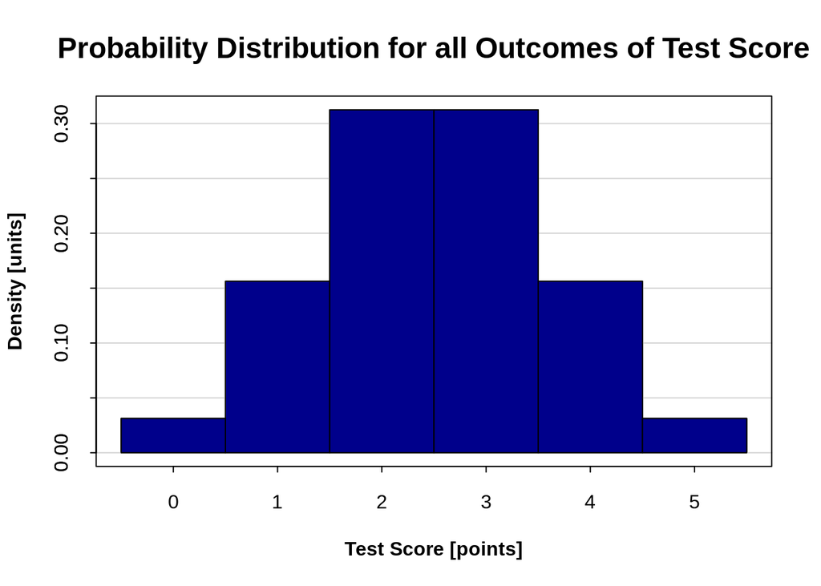

```r
hist(X, breaks=seq(-0.5, 5.5, 1), freq=F, col="darkblue", xaxt="n", yaxt="n", ylab = 'Density [units]', xlab="Test Score [points]",
     main="Probability Distribution for all Outcomes of Test Score", cex.main=1.5, cex.axis=1, cex.lab=1, font.lab=2)
axis(2, tck=1, col.ticks="light gray", lwd.ticks="1")
axis(2, tck=-0.015)
axis(1,tck=-.015)
box()
hist(X, add=TRUE, breaks=seq(-0.5, 5.5, 1), freq=F, col="darkblue", xaxt="n", yaxt="n", ylab = 'Density', xlab="Test Score [units]",
     main="Probability Distribution for all Outcomes of Test Score", cex.main=1.5, cex.axis=1, cex.lab=1,            font.lab=2)
```

> 4. Use R to calculate the population mean and population standard deviation of test scores.

```r
mu.p <- mean(X)
sigma.p <- sqrt(var(X)*((length(X)-1)/length(X)))
cat(paste0('The population mean is: ',mu.p))
```

```
## The population mean is: 2.5
```

```r
cat(paste0('The population standard deviation is: ',sigma.p))
```

```
## The population standard deviation is: 1.11803398874989
```

> 5. Set the seed to (111) and based on your pmf.p, take a SRS of size 1000 of “test scores.” Use this sample to create the PMF of the sample (call it pmf.s).

```r
set.seed(111)
size.s = 1000
s <- sample(0:5,size=size.s,replace=T,prob=pmf.p)
pmf.s <- table(s)/length(s)
```

> 6. Use R to calculate the sample mean and sample standard deviation of your 1000 sampled “test scores.”

```r
mu.s <- mean(s)
sigma.s <- sd(s)
cat(paste0('The sample mean is: ',mu.s))
```

```
## The sample mean is: 2.477
```

```r
cat(paste0('The sample standard deviation is: ',sigma.s))
```

```
## The sample standard deviation is: 1.10665970184863
```

> 7. Using the sample PMF (pmf.s), use R to construct a histogram of sampled “test scores.”

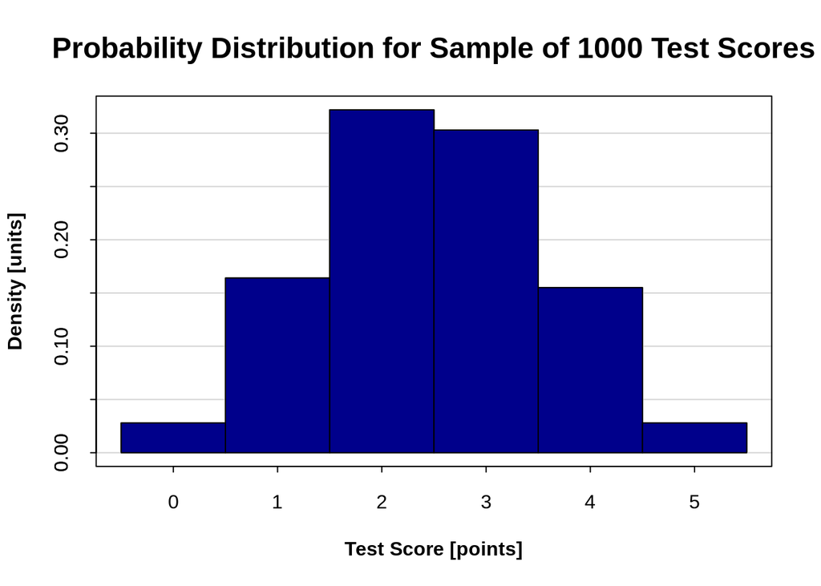

```r
hist(s, breaks=seq(-0.5, 5.5, 1),freq=F, col="darkblue", xaxt="n", yaxt="n", ylab = 'Density [units]', xlab="Test Score [points]",
     main="Probability Distribution for Sample of 1000 Test Scores", cex.main=1.5, cex.axis=1, cex.lab=1, font.lab=2)
axis(2, tck=1, col.ticks="light gray", lwd.ticks="1")
axis(2, tck=-0.015)
axis(1,tck=-.015)
box()
hist(s, add=TRUE, breaks=seq(-0.5, 5.5, 1),freq=F, col="darkblue", xaxt="n", yaxt="n", ylab = 'Density', xlab="Test Score [units]",
     main="Probability Distribution for Sample of 1000 Test Scores", cex.main=1.5, cex.axis=1, cex.lab=1,            font.lab=2)
```

> 8. Compare and contrast the Shape, Center and Spread of the pmf.p and the pmf.s.